# Spotify Songs

## Investigation Overview

In this investigation, I wanted to look at the characteristics of songs that could be used to recommend a song to any user with any taste in music.

## Dataset Overview

Spotify is an audio streaming platform that that provides DRM-restricted music, videos and podcasts from record labels and media companies. It has over 50 million tracks which user can browse using various parameters like artist, album, genre, or via playlists.It pays the artists or the right holders via royalties which is approximately 70% of thier revenue. Thus, it is also a good platform for musicians to not only showcase their talent but also to make some money.

Data Source: https://rstudio-pubs-static.s3.amazonaws.com/594296_61801bd1dbd745b5b0dde95eb49dc60b.html

## The distribution of liveness

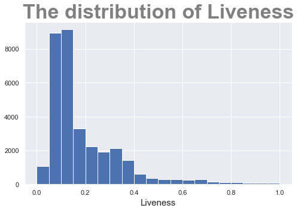

```python
# start with a standard-scaled plot
sb.set()
binsize = 0.05
bins = np.arange(0, Songs['liveness'].max()+binsize, binsize)

plt.figure(figsize=[8, 5])
plt.hist(data = Songs, x = 'liveness', bins = bins)
plt.xlabel('Liveness',fontsize='15')
plt.title("The distribution of Liveness",fontsize=34,weight='bold',color='grey');
plt.show()
```

The liveness of a song is a parameter that detects the presence of an audience in the recording, from the graph we can see that it varies from (0 "lowest" to 1 "highest" ).The most songs has a liveness rate of about 0.1

## The most occurrence genres

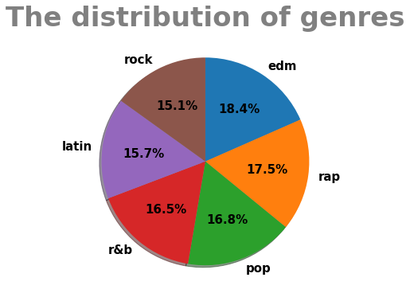

```python
sb.reset_orig()
sorted_counts = Songs['playlist_genre'].value_counts()
plt.figure(figsize=[6, 6])
plt.pie(sorted_counts, labels = sorted_counts.index, startangle = 90, counterclock = False,
        autopct='%1.1f%%',textprops={'color':"black",'fontsize':"15",'weight':"bold"},shadow=True);
plt.title("The distribution of genres",fontsize=34,weight='bold',color='grey');
```

Edm and rap songs have the most occurrence.

## Do all songs have the same duration ?

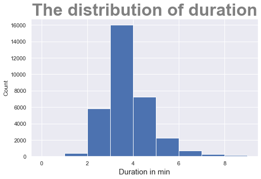

```python
# start with a standard-scaled plot
sb.set()
binsize = 1
bins = np.arange(0, Songs['duration_mins'].max()+binsize, binsize)
sb.set()
plt.figure(figsize=[8, 5])
plt.hist(data = Songs, x = 'duration_mins', bins = bins)
plt.xlabel('Duration in min',fontsize='15')
plt.ylabel("Count")
plt.title("The distribution of duration",fontsize=34,weight='bold',color='grey');
plt.show()
```

The duration of songs varies between 1 min to abour 9 mins, but in most of the songs , the duration is about 3.5 mins

## The distribution of danceability of songs

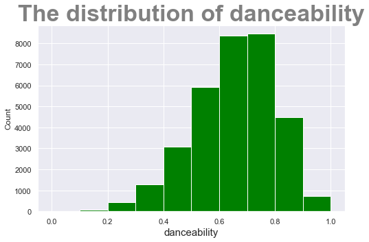

```python
# start with a standard-scaled plot

binsize = 0.1
bins = np.arange(0, Songs['danceability'].max()+binsize, binsize)
sb.set()
plt.figure(figsize=[8, 5])
plt.hist(data = Songs, x = 'danceability', bins = bins,color='green')
plt.xlabel('danceability',fontsize='15')
plt.ylabel("Count")
plt.title("The distribution of danceability",fontsize=34,weight='bold',color='grey');
plt.show()
```

From the above graph, we can see that the danceability of songs is a variable that falls between 0 and 1 , In most songs it varies between 0.6 and 0.8

## The distribution of Energy

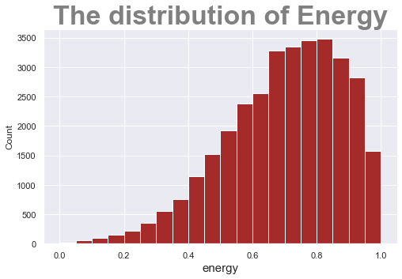

```python
# start with a standard-scaled plot

binsize =0.05
bins = np.arange(0, Songs['energy'].max()+binsize, binsize)
sb.set()
plt.figure(figsize=[8, 5])
plt.hist(data = Songs, x = 'energy', bins = bins,color='brown')
plt.xlabel('energy',fontsize='15')
plt.ylabel("Count")
plt.title("The distribution of Energy",fontsize=34,weight='bold',color='grey');

plt.show()
```

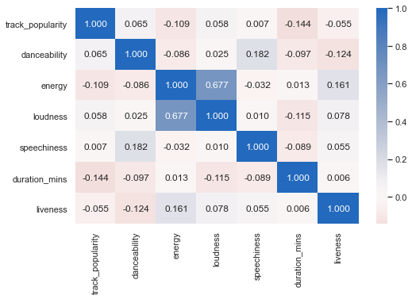

```python
# correlation plot
sb.set()
plt.figure(figsize = [8, 5])
sb.heatmap(Songs[numeric_vars].corr(), annot = True, fmt = '.3f',
           cmap = 'vlag_r', center = 0)
plt.show()
```

As it's logically expected, the lodness is positive correlated with energy (When the loudness of a song increases the energy of provided by it is ,indeed, increased)

## The Relation between loudness and energy more closely

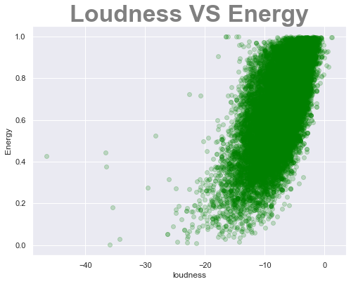

```python
plt.figure(figsize = [8, 6])
plt.scatter(data = Songs, x = 'loudness', y = 'energy',alpha=0.2,color='green')
plt.xlabel('loudness')
plt.ylabel('Energy')

plt.title("Loudness VS Energy",fontsize=34,weight='bold',color='grey');
plt.show()
```

## The most popular genres of songs

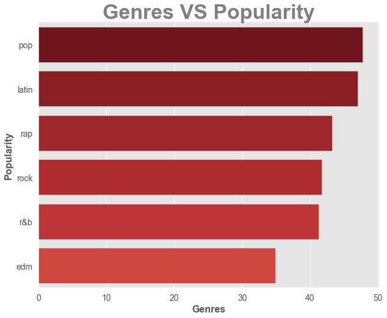

```python
plt.style.use('ggplot')
plt.figure(figsize=(10,8))
# Get the most '10' dark 'red' degrees out of '101' degree and '6' degree between each one
dark_reds = get_dark_colors(101, 6, 'Reds', 10)
dark_reds.reverse() # reverse it
sb.barplot(x=genre_ordered.values,y=genre_ordered.index,color='#008080',palette=dark_reds)
sb.despine(left=True, bottom=True) # Remove plot borders
plt.xlabel("Genres",fontsize=16,weight='bold')
plt.ylabel("Popularity",fontsize=16,weight='bold')
plt.xticks(fontsize=14);
plt.yticks(fontsize=14);
plt.title("Genres VS Popularity",fontsize=34,weight='bold',color='grey');
```

As shown above, The most popular songs are Pop, Latin and Rap songs , The least popular songs are edm and r&b songs

## In general, have the duration of songs decreased over time ?

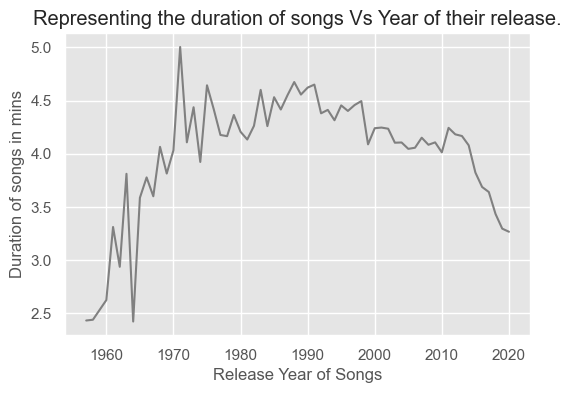

```python
#we want to know the vote_count of movies for every year therefore we have to sum up all the movies of a particular year

duration_year = Songs.groupby('year')['duration_mins'].mean()

#figure size(width, height)
plt.figure(dpi =100)

#x-axis
plt.xlabel('Release Year of Songs', fontsize = 12)
#y-axis
plt.ylabel('Duration of songs in mins', fontsize = 12)
#title
plt.title('Representing the duration of songs Vs Year of their release.')

#plotting the graph
plt.plot(duration_year,color='grey')

#displaying the line plot
plt.show()
```

From the graph above, the duration of songs was increasing during the period of (1960 - 1990) till it reached about 5 mins or more and after this period till now, the duration of song is decreasing to be about 3 - 3.5 mins

## The most popular artists from 2019 : 2020

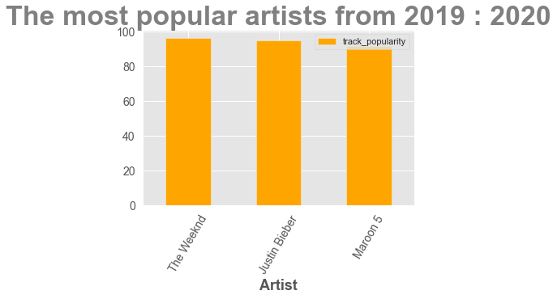

```python
popular_artists.sort_values('track_popularity',ascending=False).nlargest(3, 'track_popularity').plot.bar(x='track_artist', y='track_popularity',color='orange',fontsize=14);
plt.xlabel("Artist", fontsize=18,weight='bold');
plt.xticks(rotation='60');
plt.title("The most popular artists from 2019 : 2020",fontsize=34,weight='bold',color='grey');
```

The most popular singers/bands nowadays are "The Weeknd, Justin Bieber, Maroon5"

## The most popular songs in 2018-2020

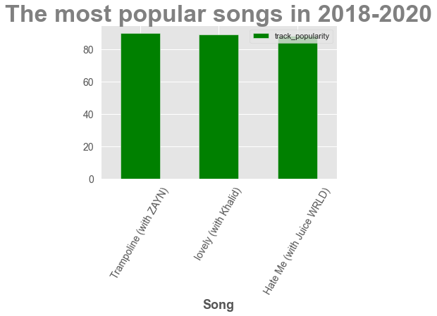

```python
df_song=Songs[Songs['year']>=2018 ].copy()
df_song.drop_duplicates(subset ="track_name",
                     keep = False, inplace = True)
df_song.nlargest(3, 'track_popularity').sort_values('track_popularity',ascending=False).plot.bar(x='track_name', y='track_popularity',color='green',fontsize=14);
plt.xticks(rotation='60');
plt.xlabel("Song", fontsize=18,weight='bold');
plt.title("The most popular songs in 2018-2020",fontsize=34,weight='bold',color='grey');
```

As shown from the above bar plot, the most popular songs in the period from (2018-2020) are : Trampolin, Lovely , Hate Me

## The most popular song of Billie Eilish's album "WHEN WE ALL FALL ASLEEP, WHERE DO WE GO?"

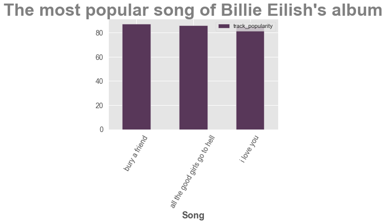

```python
Billie_Eilish=Songs[Songs['track_artist']=='Billie Eilish'].copy()
album=Billie_Eilish[Billie_Eilish['track_album_name']=="WHEN WE ALL FALL ASLEEP, WHERE DO WE GO?"].copy()
album.drop_duplicates(subset ="track_name",
                     keep = False, inplace = True)
album.nlargest(3, 'track_popularity').sort_values('track_popularity',ascending=False).plot.bar(x='track_name', y='track_popularity',color='#583759',fontsize=14);
plt.xticks(rotation='60');
plt.title("The most popular song of Billie Eilish's album",fontsize=34,weight='bold',color='grey');
plt.xlabel("Song", fontsize=18,weight='bold');
```

My favourite singer is Billie Eilish, and thus, I was very interested in exploring her songs, From the above bar plot, The most popular songs from her latest album "WHEN WE ALL FALL ASLEEP, WHERE DO WE GO?" are: bury a friend, all the good girls go to hell, I love you

## Which genres gives the most energy?

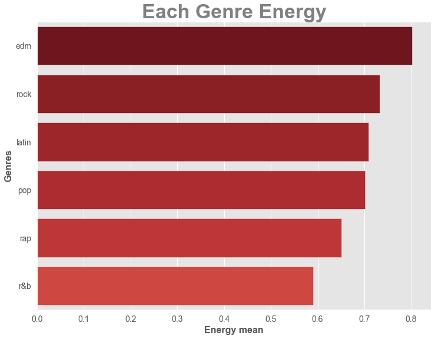

```python
plt.style.use('ggplot')
plt.figure(figsize=(12,9))
sb.barplot(x=genre_ordered.values,y=genre_ordered.index,palette=dark_reds)
plt.ylabel("Genres",fontsize=16,weight='bold')
plt.xlabel("Energy mean",fontsize=16,weight='bold')
plt.xticks(fontsize=14);
plt.yticks(fontsize=14);
plt.title("Each Genre Energy",fontsize=34,weight='bold',color='grey');
```

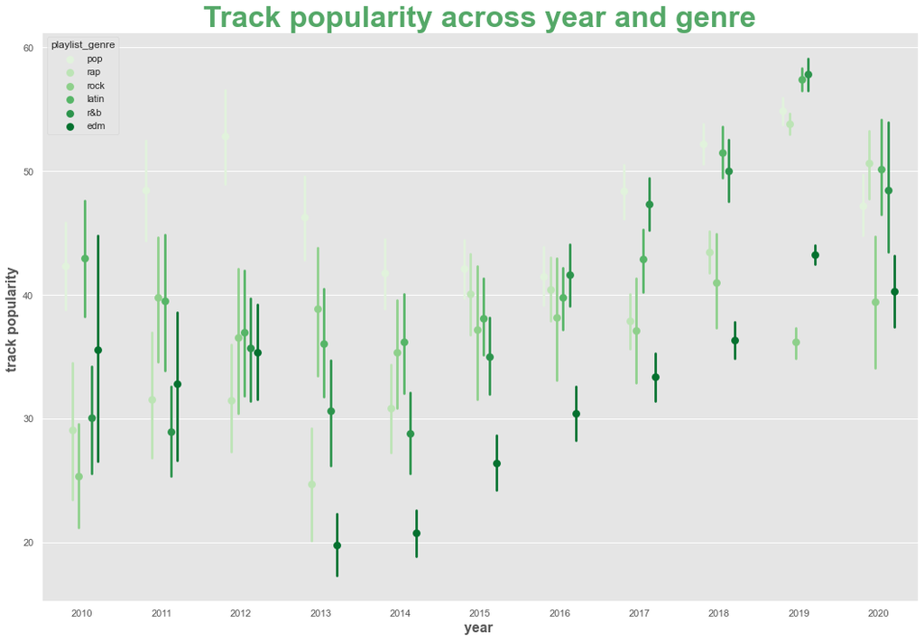

```python
fig = plt.figure(figsize = [18,12])
recent_songs=Songs[Songs['year']>=2010]
ax = sb.pointplot(data = recent_songs, x = 'year', y = 'track_popularity', hue = 'playlist_genre',
           palette = 'Greens', linestyles = '', dodge = 0.4)
plt.title('Track popularity across year and genre',fontsize=34,weight='bold',color='g')
plt.ylabel('track popularity ',fontsize=16,weight='bold')
plt.xlabel('year ',fontsize=16,weight='bold')
ax.set_yticklabels([],minor = True)
##plt.tight_layout() # Improve appearance
plt.show();
```

[figure not shown]

```python
# Get type frequencies
tracks_artists = recent_songs.track_artist.value_counts()

from matplotlib.colors import LinearSegmentedColormap
from wordcloud import WordCloud

# Get the most '12' dark 'red' degrees out of '100' degree and '7' degree between each one
dard_reds = get_dark_colors(100, 7, 'Reds', 12)
dard_reds = LinearSegmentedColormap.from_list('mycmap', dard_reds) # Create custome colormap

# Create word cloud object
wordcloud2 = WordCloud(width = 3000,
                       height = 2000,
                       background_color ='white',
                       random_state=1,
                       collocations=False,
                       min_font_size=50,
                       colormap='rocket').generate_from_frequencies(tracks_artists)

plt.figure(figsize=(20,20)) # Set figsize
plt.imshow(wordcloud2) # Plot the word cloud
plt.axis("off") # Remove axis

plt.title('Word Cloud with All the artists names from 2018 - 2020',fontsize=60, weight='bold', color = '#c60000') # Set title
plt.tight_layout() # Improve appearance
```

# Resources

- https://github.com/madesouky/Crimes-in-Chicago/blob/main/03_Slideshow.ipynb
- https://seaborn.pydata.org/generated/seaborn.barplot.html
- https://seaborn.pydata.org/generated/seaborn.lineplot.html